# Descubrimiento de comunidades

En el ámbito del analisis de redes biologicas, el descubrimiento de comunidades permite agrupar los nodos aludiendo a funcionalidad comun o alto grado de relación. En este Notebook se realiza un proceso de descubrimiento de comunidades para la red de oncogenes objeto de estudio.

Se cargan las bibliotecas necesarias.

```r
library(igraph)
library(readxl)
library(dplyr)
```

Se carga el grafo

```r
#Cargo datos
aristas <- read_excel("./Dataset1.xlsx",
                    sheet = "WeigthedNetwork")
nodos <- read_excel("./Dataset1.xlsx",
                    sheet = "NetworkNodes")
#Construyo el grafo
grafo_origen <-
  graph_from_data_frame(d = aristas, vertices = nodos,  directed=F)

#Podo cogiendo como umbral 0.4
grafo <- delete_edges(grafo_origen, E(grafo_origen)[PESO<0.4])
```

Detección de comunidades basada en propagación de etiquetas.

Primero creo un vector con numeros aleatorios que sirve para inicializar el algoritmo (si no, en cada ejecución dará resultados diferentes).

```r
set.seed(55)
inicio<-sample(c(0:176), size = 177, replace = TRUE)
```

Aplico el algoritmo.

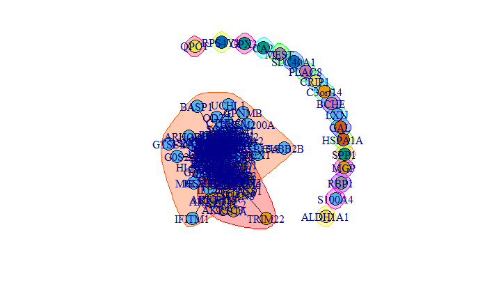

```r
clp <- cluster_label_prop(grafo, initial = inicio)
plot(clp, grafo)
```

Observamos propiedades de las comunidades descubiertas.

Las comunidades y el número de nodos que tiene cada una. Aparecen 20 comunidades: - 18 con un solo nodo - Comunidad 1: 42 nodos - Comunidad 2: 117 nodos

```r
table(clp$membership)
```

```
  1   2   3   4   5   6   7   8   9  10  11  12  13  14  15  16  17  18  19  20
 42 117   1   1   1   1   1   1   1   1   1   1   1   1   1   1   1   1   1   1
```

A que comunidad (que etiqueta tiene) pertenece cada uno de los nodos.

```r
comunidad <- clp$membership
miembros <- data.frame(nodos, comunidad)
miembros[order(-comunidad),]
```

|  | NODOS | comunidad |
| --- | --- | --- |
| 166 | QPCT | 20 |
| 163 | GPX3 | 19 |
| 158 | S100A4 | 18 |
| 157 | MGP | 17 |
| 156 | RBP1 | 16 |
| 155 | BCHE | 15 |
| 149 | GAL | 14 |
| 144 | SLC40A1 | 13 |
| 123 | CRIP1 | 12 |
| 121 | CA2 | 11 |

[output cut: 167 more lines]

```r
c2 <- filter(miembros, comunidad == 2)
#c2$NODOS
c1 <- filter(miembros, comunidad == 1)
c1$NODOS
```

```
 [1] "KRT19"     "EPCAM"     "TACSTD2"   "MAL2"      "AGR2"      "VIM"       "SRGN"
 [8] "S100P"     "DSP"       "MIR205HG"  "SPINT2"    "AKR1C3"    "AKR1C2"    "ESRP1"
[15] "TSPAN8"    "LCN2"      "RAB25"     "SERPINB5"  "CSTA"      "AKR1B10"   "SFN"
[22] "CEACAM6"   "HLA-DPA1"  "GPX2"      "RNF128"    "AKR1C1"    "IFI16"     "NMU"
[29] "C10orf116" "TSTD1"     "FOXQ1"     "GALNT3"    "GDA"       "EMP3"      "FOXA1"
[36] "DMKN"      "SLPI"      "TRIM22"    "DSG2"      "GYPC"      "TOX3"      "ASS1"
```

Selecciono las comunidades con mayor numero de nodos (la 1 y la 2) y las estudio en relación a las medidas de centralidad calculadas anteriormente.

- Degree (grado)

```r
deg <- degree(grafo, mode = "all")
degdf <- data.frame(nodos, deg)
juntos <-merge(x=degdf, miembros, by= "NODOS")
c1 <- filter(juntos, comunidad == 1)
c2 <- filter(juntos, comunidad == 2)
c1[order(-c1$deg),]
```

|  | NODOS | deg | comunidad |
| --- | --- | --- | --- |
| 12 | DSP | 47 | 1 |
| 24 | KRT19 | 47 | 1 |
| 11 | DSG2 | 44 | 1 |
| 14 | EPCAM | 44 | 1 |
| 17 | FOXQ1 | 44 | 1 |
| 26 | MAL2 | 44 | 1 |
| 32 | SERPINB5 | 44 | 1 |
| 37 | TACSTD2 | 44 | 1 |
| 33 | SFN | 43 | 1 |
| 25 | LCN2 | 39 | 1 |

[output cut: 32 more lines]

```r
c2[order(-c2$deg),]
```

|  | NODOS | deg | comunidad |
| --- | --- | --- | --- |
| 46 | GPX8 | 80 | 2 |
| 29 | CYR61 | 77 | 2 |
| 31 | DKK3 | 77 | 2 |
| 39 | FSTL1 | 77 | 2 |
| 72 | MYOF | 77 | 2 |
| 104 | TGFBI | 75 | 2 |
| 70 | MYB | 73 | 2 |
| 86 | PRSS23 | 72 | 2 |
| 91 | RND3 | 72 | 2 |
| 95 | SERPINE1 | 72 | 2 |

[output cut: 107 more lines]

- Centrality (centralidad)

```r
cent_eing <- centr_eigen(grafo, directed = F, normalized = T)
eigencen <- data.frame(nodos, cent_eing$vector)
juntos <-merge(x=eigencen, miembros, by= "NODOS")
c1 <- filter(juntos, comunidad == 1)
c2 <- filter(juntos, comunidad == 2)
c1[order(-c1$cent_eing.vector),]
```

|  | NODOS | cent_eing.vector | comunidad |
| --- | --- | --- | --- |
| 11 | DSG2 | 0.3324927619 | 1 |
| 12 | DSP | 0.3022543828 | 1 |
| 24 | KRT19 | 0.2779780360 | 1 |
| 37 | TACSTD2 | 0.2773834463 | 1 |
| 17 | FOXQ1 | 0.2478717989 | 1 |
| 33 | SFN | 0.2425356545 | 1 |
| 42 | VIM | 0.2146015109 | 1 |
| 26 | MAL2 | 0.2130654382 | 1 |
| 25 | LCN2 | 0.2125803509 | 1 |
| 32 | SERPINB5 | 0.2109693715 | 1 |

[output cut: 32 more lines]

```r
c2[order(-c2$cent_eing.vector),]
```

|  | NODOS | cent_eing.vector | comunidad |
| --- | --- | --- | --- |
| 46 | GPX8 | 1.000000000 | 2 |
| 29 | CYR61 | 0.992041344 | 2 |
| 104 | TGFBI | 0.976716666 | 2 |
| 70 | MYB | 0.962067558 | 2 |
| 86 | PRSS23 | 0.952521061 | 2 |
| 31 | DKK3 | 0.942656689 | 2 |
| 39 | FSTL1 | 0.930436640 | 2 |
| 12 | CAV1 | 0.928405461 | 2 |
| 72 | MYOF | 0.923836951 | 2 |
| 91 | RND3 | 0.921369803 | 2 |

[output cut: 107 more lines]

- Clossenes (cercanía)

```r
cent_clo <-centr_clo(grafo, mode = "all", normalized = T)
```

```
At centrality.c:2784 :closeness centrality is not well-defined for disconnected graphs
```

```r
clossenes <- data.frame(nodos, cent_clo$res)
juntos <-merge(x=clossenes, miembros, by= "NODOS")
c1 <- filter(juntos, comunidad == 1)
c2 <- filter(juntos, comunidad == 2)
c1[order(-c1$cent_clo.res),]
```

|  | NODOS | cent_clo.res | comunidad |
| --- | --- | --- | --- |
| 42 | VIM | 0.05066206 | 1 |
| 14 | EPCAM | 0.05064748 | 1 |
| 33 | SFN | 0.05064748 | 1 |
| 26 | MAL2 | 0.05063291 | 1 |
| 35 | SPINT2 | 0.05061835 | 1 |
| 12 | DSP | 0.05060380 | 1 |
| 37 | TACSTD2 | 0.05060380 | 1 |
| 24 | KRT19 | 0.05057471 | 1 |
| 29 | RAB25 | 0.05057471 | 1 |
| 15 | ESRP1 | 0.05056018 | 1 |

[output cut: 32 more lines]

```r
c2[order(-c2$cent_clo.res),]
```

|  | NODOS | cent_clo.res | comunidad |
| --- | --- | --- | --- |
| 72 | MYOF | 0.05128205 | 2 |
| 46 | GPX8 | 0.05123726 | 2 |
| 39 | FSTL1 | 0.05122235 | 2 |
| 29 | CYR61 | 0.05120745 | 2 |
| 104 | TGFBI | 0.05117767 | 2 |
| 31 | DKK3 | 0.05114792 | 2 |
| 91 | RND3 | 0.05114792 | 2 |
| 95 | SERPINE1 | 0.05114792 | 2 |
| 70 | MYB | 0.05113306 | 2 |
| 35 | F3 | 0.05111821 | 2 |

[output cut: 107 more lines]

- Betweenness (intermediación)

```r
bet <- betweenness(grafo, directed = F)
betdf <- data.frame(nodos, bet)
juntos <-merge(x=betdf, miembros, by= "NODOS")
c1 <- filter(juntos, comunidad == 1)
c2 <- filter(juntos, comunidad == 2)
c1[order(-c1$bet),]
```

|  | NODOS | bet | comunidad |
| --- | --- | --- | --- |
| 17 | FOXQ1 | 260.41255794 | 1 |
| 42 | VIM | 254.20630548 | 1 |
| 32 | SERPINB5 | 219.82286501 | 1 |
| 14 | EPCAM | 209.49507301 | 1 |
| 20 | GPX2 | 184.68625159 | 1 |
| 13 | EMP3 | 183.50006395 | 1 |
| 23 | IFI16 | 159.92165961 | 1 |
| 12 | DSP | 140.48760630 | 1 |
| 24 | KRT19 | 134.14113787 | 1 |
| 35 | SPINT2 | 111.62798633 | 1 |

[output cut: 32 more lines]

```r
c2[order(-c2$bet),]
```

|  | NODOS | bet | comunidad |
| --- | --- | --- | --- |
| 99 | SPARC | 539.12812655 | 2 |
| 67 | MAP1B | 386.45339083 | 2 |
| 87 | PTGR1 | 356.67947703 | 2 |
| 101 | SRPX | 337.18702926 | 2 |
| 35 | F3 | 321.08575522 | 2 |
| 72 | MYOF | 320.97745594 | 2 |
| 11 | C19orf33 | 315.50158672 | 2 |
| 91 | RND3 | 310.33880882 | 2 |
| 116 | VEGFC | 308.50489103 | 2 |
| 45 | GPRC5A | 283.13609925 | 2 |

[output cut: 107 more lines]

Detección de comunidades basadas en optimización de modularidad.

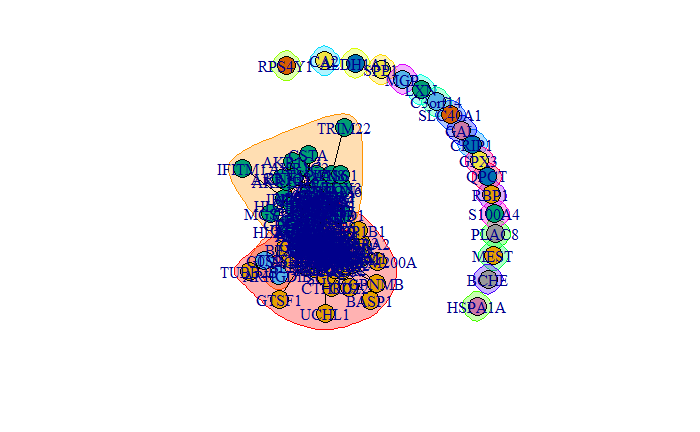

```r
cfg <- cluster_fast_greedy(grafo)
plot(cfg, grafo)
```

Observamos propiedades de las comunidades descubiertas.

```r
table(cfg$membership)
```

```
 1  2  3  4  5  6  7  8  9 10 11 12 13 14 15 16 17 18 19 20 21
87  8 64  1  1  1  1  1  1  1  1  1  1  1  1  1  1  1  1  1  1
```

Comunidad a la que pertenece cada nodo.

```r
comunidad <- cfg$membership
miembros <- data.frame(nodos, comunidad)
miembros[order(-comunidad),]
```

|  | NODOS | comunidad |
| --- | --- | --- |
| 166 | QPCT | 21 |
| 163 | GPX3 | 20 |
| 158 | S100A4 | 19 |
| 157 | MGP | 18 |
| 156 | RBP1 | 17 |
| 155 | BCHE | 16 |
| 149 | GAL | 15 |
| 144 | SLC40A1 | 14 |
| 123 | CRIP1 | 13 |
| 121 | CA2 | 12 |

[output cut: 167 more lines]

```r
c3 <- filter(miembros, comunidad == 3)
#c3$NODOS
c2 <- filter(miembros, comunidad == 2)
#c2$NODOS
c1 <- filter(miembros, comunidad == 1)
#c1$NODOS
```

- Degree (grado)

```r
deg <- degree(grafo, mode = "all")
degdf <- data.frame(nodos, deg)
juntos <-merge(x=degdf, miembros, by= "NODOS")
c1 <- filter(juntos, comunidad == 1)
c2 <- filter(juntos, comunidad == 2)
c3 <- filter(juntos, comunidad == 3)
c1[order(-c1$deg),]
```

|  | NODOS | deg | comunidad |
| --- | --- | --- | --- |
| 31 | GPX8 | 80 | 1 |
| 19 | CYR61 | 77 | 1 |
| 21 | DKK3 | 77 | 1 |
| 27 | FSTL1 | 77 | 1 |
| 75 | TGFBI | 75 | 1 |
| 45 | MYB | 73 | 1 |
| 59 | PRSS23 | 72 | 1 |
| 63 | RND3 | 72 | 1 |
| 66 | SERPINE1 | 72 | 1 |
| 86 | VEGFC | 72 | 1 |

[output cut: 77 more lines]

```r
c2[order(-c2$deg),]
```

|  | NODOS | deg | comunidad |
| --- | --- | --- | --- |
| 1 | ARHGAP29 | 63 | 2 |
| 8 | PTGR1 | 62 | 2 |
| 7 | PLAU | 49 | 2 |
| 4 | HCLS1 | 29 | 2 |
| 6 | LCP1 | 21 | 2 |
| 5 | HLA-DRA | 12 | 2 |
| 2 | ARHGDIB | 3 | 2 |
| 3 | G0S2 | 2 | 2 |

```r
c3[order(-c3$deg),]
```

|  | NODOS | deg | comunidad |
| --- | --- | --- | --- |
| 47 | MYOF | 77 | 3 |
| 25 | F3 | 67 | 3 |
| 31 | GPRC5A | 66 | 3 |
| 51 | S100A2 | 61 | 3 |
| 11 | C19orf33 | 60 | 3 |
| 59 | TM4SF1 | 59 | 3 |
| 41 | LAMB3 | 57 | 3 |
| 7 | ANXA3 | 54 | 3 |
| 6 | ALDH1A3 | 51 | 3 |
| 14 | CLDN1 | 48 | 3 |

[output cut: 54 more lines]

- Centrality (centralidad)

```r
cent_eing <- centr_eigen(grafo, directed = F, normalized = T)
eigencen <- data.frame(nodos, cent_eing$vector)
juntos <-merge(x=eigencen, miembros, by= "NODOS")
c1 <- filter(juntos, comunidad == 1)
c2 <- filter(juntos, comunidad == 2)
c3 <- filter(juntos, comunidad == 3)
c1[order(-c1$cent_eing.vector),]
```

|  | NODOS | cent_eing.vector | comunidad |
| --- | --- | --- | --- |
| 31 | GPX8 | 1.000000000 | 1 |
| 19 | CYR61 | 0.992041344 | 1 |
| 75 | TGFBI | 0.976716666 | 1 |
| 45 | MYB | 0.962067558 | 1 |
| 59 | PRSS23 | 0.952521061 | 1 |
| 21 | DKK3 | 0.942656689 | 1 |
| 27 | FSTL1 | 0.930436640 | 1 |
| 6 | CAV1 | 0.928405461 | 1 |
| 63 | RND3 | 0.921369803 | 1 |
| 26 | FRMD6 | 0.919383734 | 1 |

[output cut: 77 more lines]

```r
c2[order(-c2$cent_eing.vector),]
```

|  | NODOS | cent_eing.vector | comunidad |
| --- | --- | --- | --- |
| 1 | ARHGAP29 | 0.82638252 | 2 |
| 8 | PTGR1 | 0.80255071 | 2 |
| 7 | PLAU | 0.65900318 | 2 |
| 4 | HCLS1 | 0.34035123 | 2 |
| 6 | LCP1 | 0.27040781 | 2 |
| 5 | HLA-DRA | 0.12084774 | 2 |
| 3 | G0S2 | 0.02791821 | 2 |
| 2 | ARHGDIB | 0.01985775 | 2 |

```r
c3[order(-c3$cent_eing.vector),]
```

|  | NODOS | cent_eing.vector | comunidad |
| --- | --- | --- | --- |
| 47 | MYOF | 0.9238369513 | 3 |
| 25 | F3 | 0.7724283163 | 3 |
| 59 | TM4SF1 | 0.7605709816 | 3 |
| 51 | S100A2 | 0.7406643692 | 3 |
| 31 | GPRC5A | 0.6523088057 | 3 |
| 6 | ALDH1A3 | 0.6350366921 | 3 |
| 43 | LGALS3 | 0.5718069199 | 3 |
| 41 | LAMB3 | 0.5149674370 | 3 |
| 12 | CD9 | 0.5011157963 | 3 |
| 14 | CLDN1 | 0.5010487410 | 3 |

[output cut: 54 more lines]

- Clossenes (cercanía)

```r
cent_clo <-centr_clo(grafo, mode = "all", normalized = T)
```

```
At centrality.c:2784 :closeness centrality is not well-defined for disconnected graphs
```

```r
clossenes <- data.frame(nodos, cent_clo$res)
juntos <-merge(x=clossenes, miembros, by= "NODOS")
c1 <- filter(juntos, comunidad == 1)
c2 <- filter(juntos, comunidad == 2)
c3 <- filter(juntos, comunidad == 3)
c1[order(-c1$cent_clo.res),]
```

|  | NODOS | cent_clo.res | comunidad |
| --- | --- | --- | --- |
| 31 | GPX8 | 0.05123726 | 1 |
| 27 | FSTL1 | 0.05122235 | 1 |
| 19 | CYR61 | 0.05120745 | 1 |
| 75 | TGFBI | 0.05117767 | 1 |
| 21 | DKK3 | 0.05114792 | 1 |
| 63 | RND3 | 0.05114792 | 1 |
| 66 | SERPINE1 | 0.05114792 | 1 |
| 45 | MYB | 0.05113306 | 1 |
| 59 | PRSS23 | 0.05111821 | 1 |
| 72 | SRPX | 0.05108853 | 1 |

[output cut: 77 more lines]

```r
c2[order(-c2$cent_clo.res),]
```

|  | NODOS | cent_clo.res | comunidad |
| --- | --- | --- | --- |
| 1 | ARHGAP29 | 0.05098494 | 2 |
| 8 | PTGR1 | 0.05098494 | 2 |
| 7 | PLAU | 0.05070585 | 2 |
| 4 | HCLS1 | 0.05025700 | 2 |
| 6 | LCP1 | 0.05000000 | 2 |
| 5 | HLA-DRA | 0.04978784 | 2 |
| 2 | ARHGDIB | 0.04891606 | 2 |
| 3 | G0S2 | 0.04888889 | 2 |

```r
c3[order(-c3$cent_clo.res),]
```

|  | NODOS | cent_clo.res | comunidad |
| --- | --- | --- | --- |
| 47 | MYOF | 0.05128205 | 3 |
| 25 | F3 | 0.05111821 | 3 |
| 31 | GPRC5A | 0.05104408 | 3 |
| 51 | S100A2 | 0.05101449 | 3 |
| 59 | TM4SF1 | 0.05097017 | 3 |
| 11 | C19orf33 | 0.05095541 | 3 |
| 7 | ANXA3 | 0.05083767 | 3 |
| 41 | LAMB3 | 0.05083767 | 3 |
| 6 | ALDH1A3 | 0.05070585 | 3 |
| 12 | CD9 | 0.05070585 | 3 |

[output cut: 54 more lines]

- Betweenness (intermediación)

```r
bet <- betweenness(grafo, directed = F)
betdf <- data.frame(nodos, bet)
juntos <-merge(x=betdf, miembros, by= "NODOS")
c1 <- filter(juntos, comunidad == 1)
c2 <- filter(juntos, comunidad == 2)
c3 <- filter(juntos, comunidad == 3)
c1[order(-c1$bet),]
```

|  | NODOS | bet | comunidad |
| --- | --- | --- | --- |
| 70 | SPARC | 539.1281266 | 1 |
| 43 | MAP1B | 386.4533908 | 1 |
| 72 | SRPX | 337.1870293 | 1 |
| 63 | RND3 | 310.3388088 | 1 |
| 86 | VEGFC | 308.5048910 | 1 |
| 8 | CNRIP1 | 278.4395466 | 1 |
| 66 | SERPINE1 | 242.9849162 | 1 |
| 27 | FSTL1 | 205.8127629 | 1 |
| 60 | PTX3 | 195.7319908 | 1 |
| 21 | DKK3 | 187.3093126 | 1 |

[output cut: 77 more lines]

```r
c2[order(-c2$bet),]
```

|  | NODOS | bet | comunidad |
| --- | --- | --- | --- |
| 8 | PTGR1 | 356.6794770 | 2 |
| 4 | HCLS1 | 125.1101096 | 2 |
| 1 | ARHGAP29 | 94.2329120 | 2 |
| 7 | PLAU | 92.8374018 | 2 |
| 6 | LCP1 | 40.8270994 | 2 |
| 5 | HLA-DRA | 8.7419509 | 2 |
| 2 | ARHGDIB | 0.3439767 | 2 |
| 3 | G0S2 | 0.0000000 | 2 |

```r
c3[order(-c3$bet),]
```

|  | NODOS | bet | comunidad |
| --- | --- | --- | --- |
| 25 | F3 | 321.08575522 | 3 |
| 47 | MYOF | 320.97745594 | 3 |
| 11 | C19orf33 | 315.50158672 | 3 |
| 31 | GPRC5A | 283.13609925 | 3 |
| 27 | FOXQ1 | 260.41255794 | 3 |
| 64 | VIM | 254.20630548 | 3 |
| 41 | LAMB3 | 242.04208457 | 3 |
| 53 | SERPINB5 | 219.82286501 | 3 |
| 22 | EPCAM | 209.49507301 | 3 |
| 32 | GPX2 | 184.68625159 | 3 |

[output cut: 54 more lines]